# Assignemnt 1

### visualize data

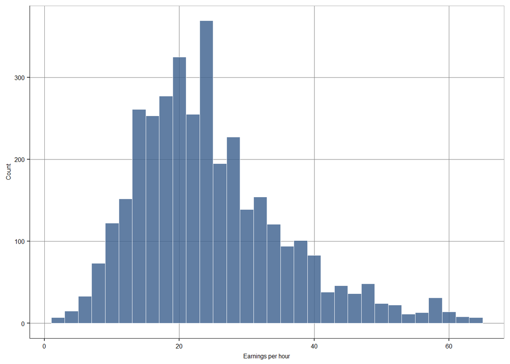

```r
# distribution of earnings per hour


hist_earnh <- ggplot(data, aes(x=earnh))+
              geom_histogram(binwidth = 2, fill = color[1], color = color.outline,
                             alpha = 0.8, size = 0.25) +
              ylab("Count") +
              xlab("Earnings per hour") +
              theme_bg()
hist_earnh
```

### label engineering

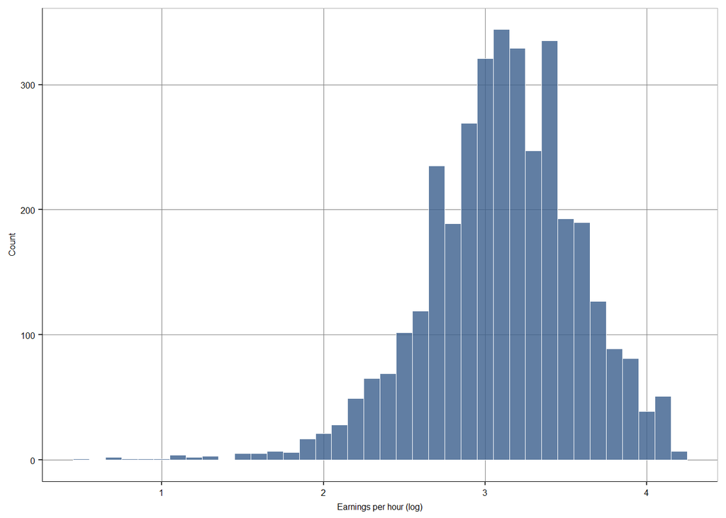

```r
### label engineering: log vs label, otherwise given:
# Use when: More interested in relative changes than in changes per currency. Log differences approximate relative, or percentage, differences, and relative price differences are often more stable.The related technical advantage is that the distribution of log prices is often close to normal, which makes linear regressions give better approximation to average differences.

#do:Look at some patterns & Compare model performance

data <- data %>% mutate(learnh=log(earnh))


hist_learnh <- ggplot(data, aes(x=learnh))+
              geom_histogram(binwidth = 0.1, fill = color[1], color =color.outline, alpha = 0.8, size = 0.25) +
              ylab("Count") +
              xlab("Earnings per hour (log)") +
              theme_bg()

hist_learnh
```

```r
# levels seems to be fine here
```

## feature engineering

### 1) missing values

```r
#1. What to do with missing values?

# where do we have missing variables in our data se?
to_filter <- sapply(data, function(x) sum(is.na(x)))
to_filter[to_filter > 0]
```

```
##   ethnic unioncov
##     3299     1827
```

```r
data$ethnic <- fct_explicit_na(as.character(data$ethnic),na_level = "Missing")
data$unioncov  <- fct_explicit_na(data$unioncov ,na_level = "Missing")

#ethnic, use race instead
#union cov, use unionmme instead - so no imputations necessary
```

### 2) & 3) ordered categorical values, text, binary variables

#2. Dealing with ordered categorical values - continuous or set of binaries #If binary (e.g, yes/no; male/female; 1/2) – create a 0/1 binary variable #3. How to use text to create variables #May simply go and find some words, and create binaries –> seminar

```r
#2a) # female (1,0) create binary!
summary(as.factor(data$sex))
```

```
##    1    2
##  637 2917
```

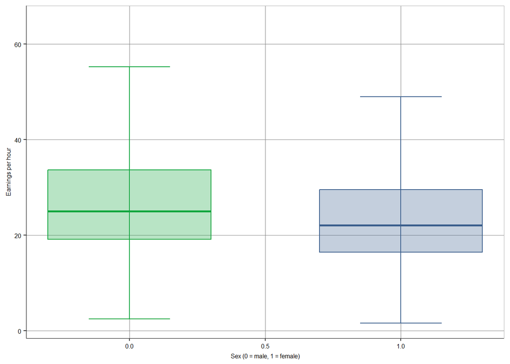

```r
data <- data %>% mutate(female=as.numeric(sex==2))

#  graph: earnings distribution male & female

boxplot_gender <- ggplot(data, aes(x = female, y = earnh)) +
  stat_boxplot(aes(group = female), geom = "errorbar", width = 0.3,
               color = c(color[2],color[1]), size = 0.5, na.rm=T)+
  geom_boxplot(aes(group = female),
               color = c(color[2],color[1]), fill = c(color[2],color[1]),
               size = 0.5, width = 0.6, alpha = 0.3, na.rm=T, outlier.shape = NA) +
  labs(x = "Sex (0 = male, 1 = female)",y = "Earnings per hour")+
  theme_bg()

boxplot_gender
```

```r
#2b) Native & Foreign create binary!

summary(as.factor(data$prcitshp))
```

```
##         Foreign Born, Not a US Citizen Foreign Born, US Cit By Naturalization
##                                     52                                    105
##    Native, Born Abroad Of US Parent(s) Native, Born in PR or US Outlying Area
##                                     31                                      8
##                     Native, Born In US
##                                   3358
```

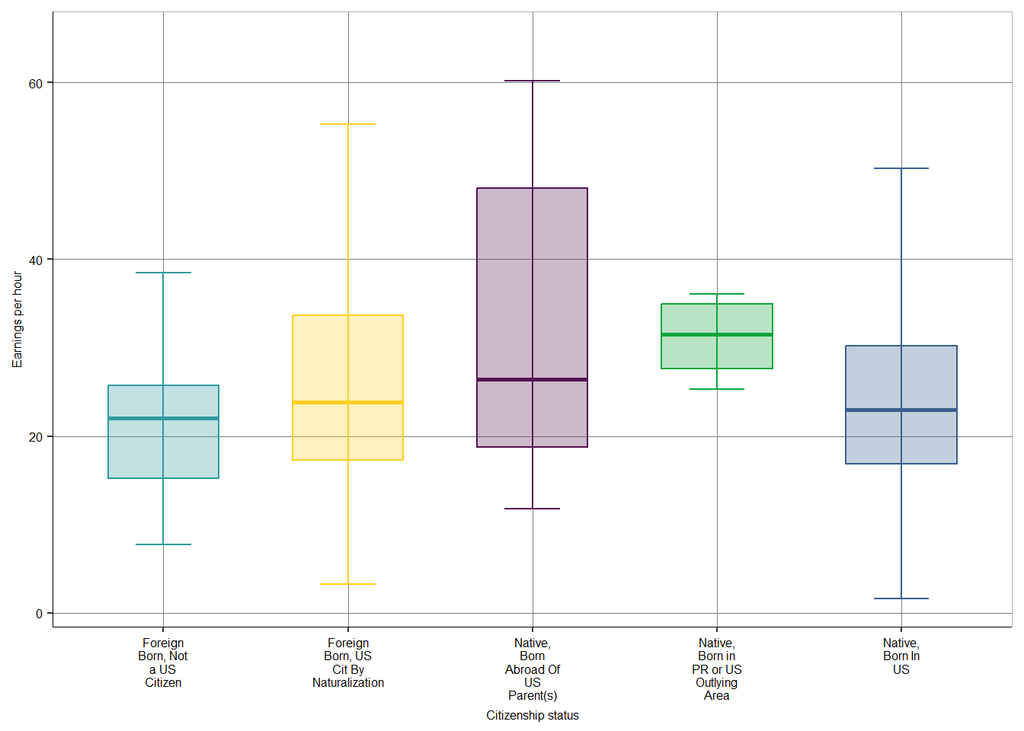

```r
# graph: earnings distribution Citizenship status (boxplot)

boxplot_native <- ggplot(data, aes(x = prcitshp, y = earnh)) +
  stat_boxplot(aes(group = prcitshp), geom = "errorbar", width = 0.3,
               color = c(color[5],color[4],color[3],color[2],color[1]), size = 0.5, na.rm=T)+
  geom_boxplot(aes(group = prcitshp),
               color = c(color[5],color[4],color[3],color[2],color[1]), fill = c(color[5],color[4],color[3],color[2],color[1]),
               size = 0.5, width = 0.6, alpha = 0.3, na.rm=T, outlier.shape = NA) +
  labs(x = "Citizenship status",y = "Earnings per hour")+
  theme_bg()+
    scale_x_discrete(labels = label_wrap(10))

boxplot_native
```

```r
# Native binary

data <- data %>% mutate(native = ifelse(prcitshp=="Native, Born Abroad Of US Parent(s)",1,ifelse(prcitshp=="Native, Born in PR or US Outlying Area",1,ifelse(prcitshp=="Native, Born In US",1,0))))

summary(as.factor(data$native))
```

```
##    0    1
##  157 3397
```

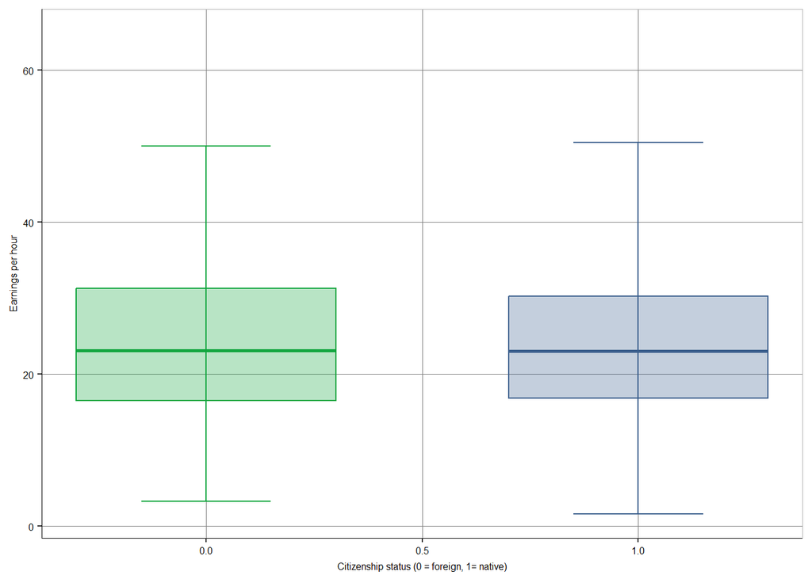

```r
# graph: earnings distribution native & foreign (boxplot)

boxplot_native2 <- ggplot(data, aes(x = native, y = earnh)) +
  stat_boxplot(aes(group = native), geom = "errorbar", width = 0.3,
               color = c(color[2],color[1]), size = 0.5, na.rm=T)+
  geom_boxplot(aes(group = native),
               color = c(color[2],color[1]), fill = c(color[2],color[1]),
               size = 0.5, width = 0.6, alpha = 0.3, na.rm=T, outlier.shape = NA) +
  labs(x = "Citizenship status (0 = foreign, 1= native)",y = "Earnings per hour")+
  theme_bg()

boxplot_native2
```

```r
data %>% dplyr::select(earnh,native) %>% filter(native==1) %>% summary()
```

```
##      earnh            native
##  Min.   : 1.603   Min.   :1
##  1st Qu.:16.827   1st Qu.:1
##  Median :23.026   Median :1
##  Mean   :24.666   Mean   :1
##  3rd Qu.:30.288   3rd Qu.:1
##  Max.   :64.900   Max.   :1
```

```r
data %>% dplyr::select(earnh,native) %>% filter(native==0) %>% summary()
```

```
##      earnh           native
##  Min.   : 3.26   Min.   :0
##  1st Qu.:16.50   1st Qu.:0
##  Median :23.08   Median :0
##  Mean   :24.91   Mean   :0
##  3rd Qu.:31.25   3rd Qu.:0
##  Max.   :62.50   Max.   :0
```

```r
#2c) # class of worker: private / gov. Create binary!

summary(as.factor(data$class))
```

```
## Government - Federal   Government - Local   Government - State
##                   20                 2148                  677
##  Private, For Profit   Private, Nonprofit
##                  438                  271
```

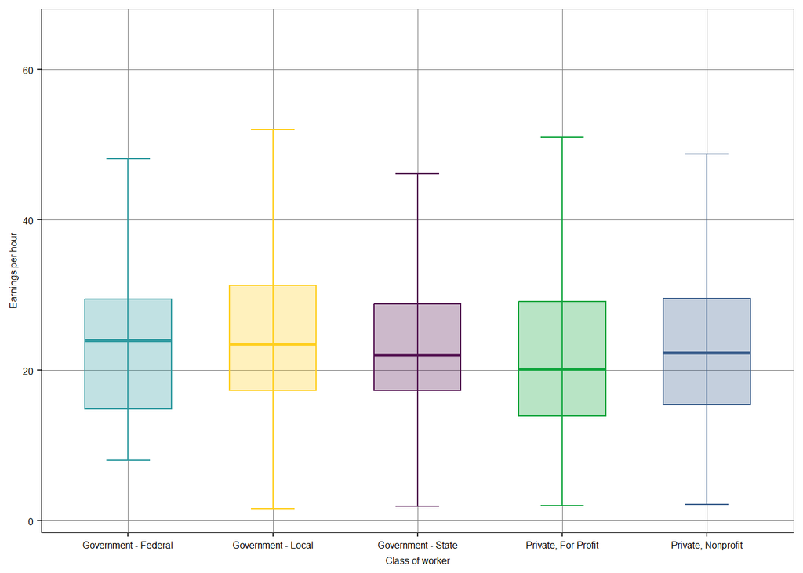

```r
boxplot_class2 <- ggplot(data, aes(x = class, y = earnh)) +
  stat_boxplot(aes(group = class), geom = "errorbar", width = 0.3,
               color = c(color[5],color[4],color[3],color[2],color[1]), size = 0.5, na.rm=T)+
  geom_boxplot(aes(group = class),
               color = c(color[5],color[4],color[3],color[2],color[1]), fill = c(color[5],color[4],color[3],color[2],color[1]),
               size = 0.5, width = 0.6, alpha = 0.3, na.rm=T, outlier.shape = NA) +
  labs(x = "Class of worker",y = "Earnings per hour")+
  theme_bg()

boxplot_class2
```

```r
# change to binary

data <- data %>% mutate(private = ifelse(class == "Private, For Profit",1,ifelse(class == "Private, Nonprofit",1,0)))

summary(as.factor(data$private))
```

```
##    0    1
## 2845  709
```

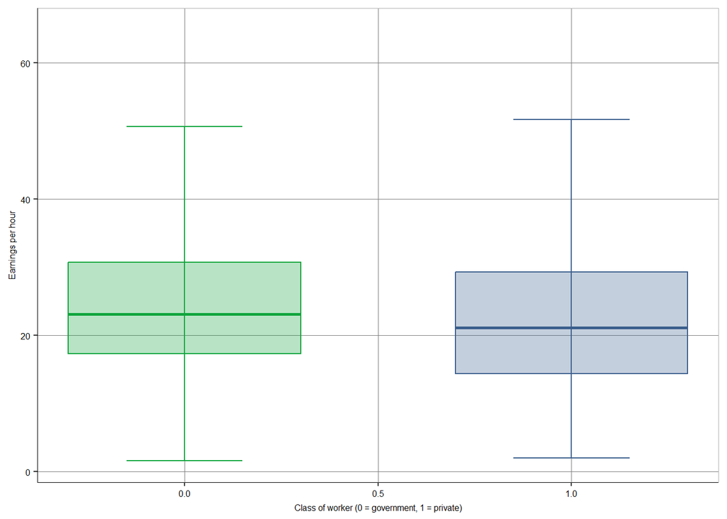

```r
boxplot_class <- ggplot(data, aes(x = private, y = earnh)) +
  stat_boxplot(aes(group = private), geom = "errorbar", width = 0.3,
               color = c(color[2],color[1]), size = 0.5, na.rm=T)+
  geom_boxplot(aes(group = private),
               color = c(color[2],color[1]), fill = c(color[2],color[1]),
               size = 0.5, width = 0.6, alpha = 0.3, na.rm=T, outlier.shape = NA) +
  labs(x = "Class of worker (0 = government, 1 = private)",y = "Earnings per hour")+
  theme_bg()

boxplot_class
```

```r
# add graph: earnings distribution private & gov (boxplot)
```

```r
#2) race binary as: white and other.

summary(as.factor(data$race))
```

```
##    1    2    3    4    5    6    7    8    9   10   11   13   15   16   21
## 3123  288   19   73   13    7    6    6    5    1    1    1    3    4    4
```

```r
data <- data %>% mutate(white = ifelse(race == 1 ,1,0))

summary(as.factor(data$white))
```

```
##    0    1
##  431 3123
```

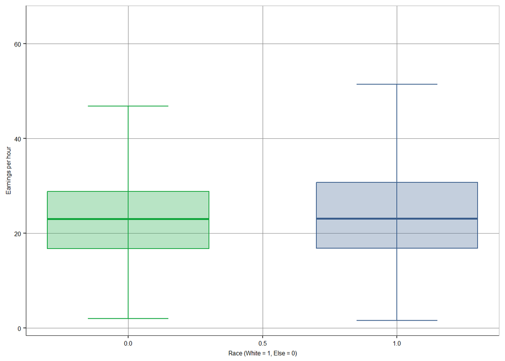

```r
boxplot_race <- ggplot(data, aes(x = white, y = earnh)) +
  stat_boxplot(aes(group = white), geom = "errorbar", width = 0.3,
               color = c(color[2],color[1]), size = 0.5, na.rm=T)+
  geom_boxplot(aes(group = white),
               color = c(color[2],color[1]), fill = c(color[2],color[1]),
               size = 0.5, width = 0.6, alpha = 0.3, na.rm=T, outlier.shape = NA) +
  labs(x = "Race (White = 1, Else = 0)",y = "Earnings per hour")+
  theme_bg()

boxplot_race
```

```r
# 2d) Education level. Create binaries.

summary(as.factor(data$grade92))
```

```
##   38   39   40   41   42   43   44   45   46
##    5   72  103   31   66 1521 1671   46   39
```

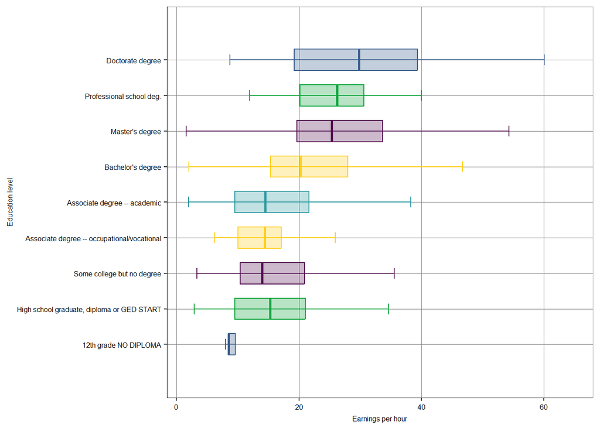

```r
#graph: earnings distribution education levels


#38 12th grade NO DIPLOMA
#39 High school graduate, diploma or GED START
#40 Some college but no degree
#41 Associate degree -- occupational/vocational
#42 Associate degree -- occupational/vocational
#43 Bachelor's degree (e.g. BA,AB,BS)
#44 Master's degree (e.g. MA,MS,MEng,Med,MSW,MBA)
#45 Professional school deg. (e.g. MD,DDS,DVM,LLB,JD)
#46 Doctorate degree (e.g. PhD, EdD)

boxplot_grade92 <- ggplot(data, aes(x = grade92, y = earnh)) +
  stat_boxplot(aes(group = grade92), geom = "errorbar", width = 0.3,
               color = c(color[1],color[2],color[3],color[4],color[5],color[4],color[3],color[2],color[1]), size = 0.5, na.rm=T)+
  geom_boxplot(aes(group = grade92),
               color = c(color[1],color[2],color[3],color[4],color[5],color[4],color[3],color[2],color[1]), fill = c(color[1],color[2],color[3],color[4],color[5],color[4],color[3],color[2],color[1]),
               size = 0.5, width = 0.6, alpha = 0.3, na.rm=T, outlier.shape = NA) +
  labs(x = "Education level",y = "Earnings per hour")+
  scale_x_continuous(limits =c(37,47), breaks = seq(38,46, 1),label = c("12th grade NO DIPLOMA", "High school graduate, diploma or GED START", "Some college but no degree","Associate degree -- occupational/vocational","Associate degree -- academic", "Bachelor's degree", "Master's degree", "Professional school deg.", "Doctorate degree"))+
  theme_bg() +
  coord_flip()

boxplot_grade92
```

```r
data  <- data %>% mutate(edu_HighS = as.numeric(grade92==38),
                        edu_BA = as.numeric(grade92==43),
                        edu_MA=as.numeric(grade92==44),
                        edu_Prof = as.numeric(grade92==45),
                        edu_PhD = as.numeric(grade92==46))
```

```r
#2e) UNION Do as 1,0
summary(as.factor(data$unionmme))
```

```
##   No  Yes
## 1727 1827
```

```r
summary(as.factor(data$unioncov))
```

```
##      No     Yes Missing
##    1565     162    1827
```

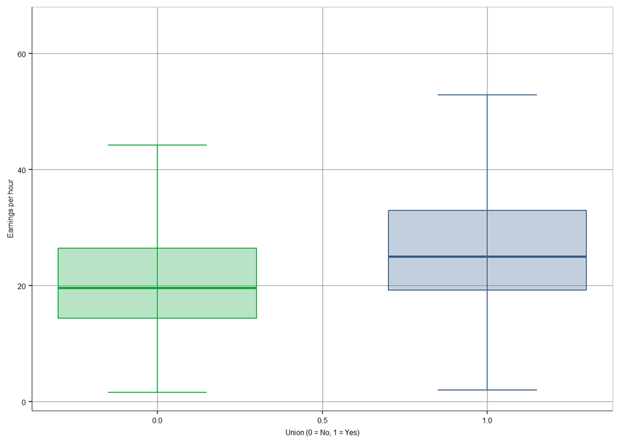

```r
data <- data %>% mutate(union = as.numeric(unionmme=="Yes" | unioncov=="Yes"))

boxplot_union <- ggplot(data, aes(x = union, y = earnh)) +
  stat_boxplot(aes(group = union), geom = "errorbar", width = 0.3,
               color = c(color[2],color[1]), size = 0.5, na.rm=T)+
  geom_boxplot(aes(group = union),
               color = c(color[2],color[1]), fill = c(color[2],color[1]),
               size = 0.5, width = 0.6, alpha = 0.3, na.rm=T, outlier.shape = NA) +
  labs(x = "Union (0 = No, 1 = Yes)",y = "Earnings per hour")+
  theme_bg()

boxplot_union
```

# Furhter demographics (family)

```r
data <- data %>% mutate(married = as.numeric(marital==1 | marital==2),
                      divorced = as.numeric(marital==3 | marital==5 | marital==6),
                      wirowed = as.numeric(marital==4),
                      nevermar = as.numeric(marital==7),
                      child0 = as.numeric(chldpres==0),
                      child1 = as.numeric(chldpres==1),
                      child2 = as.numeric(chldpres==2),
                      child3 = as.numeric(chldpres==3),
                      child4plus = as.numeric(chldpres>=4))
# no need for "ownchild" variable
```

```r
# graph group by state? mean salary by state?
# check frequency of teacher by state type
data %>%
  group_by(stfips) %>%
  dplyr::summarize(frequency=n()) %>%
  mutate(percent = frequency / sum(frequency)*100)
```

```
## # A tibble: 51 × 3
##    stfips frequency percent
##    <chr>      <int>   <dbl>
##  1 AK            56   1.58
##  2 AL            45   1.27
##  3 AR            42   1.18
##  4 AZ            33   0.929
##  5 CA           256   7.20
##  6 CO            69   1.94
##  7 CT            83   2.34
##  8 DC            47   1.32
##  9 DE            52   1.46
## 10 FL           163   4.59
## # ℹ 41 more rows
```

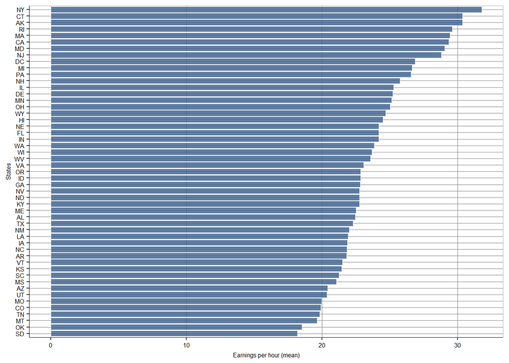

```r
# most teacher is CA,, FL, NY, TX
salary_state <- ggplot(data, aes(reorder(stfips, earnh, FUN = mean), earnh)) +
  geom_bar(position='dodge', stat='summary', fun='mean',binwidth = 0.1, fill = color[1], color =color.outline, alpha = 0.8, size = 0.25) +
   coord_flip() +
  labs(x = "States",y = "Earnings per hour (mean)")+
  theme_bg()
salary_state
```

```r
# use as fixed effects - state

# Continuous – nothing to do. Make sure it is stored as number
#glimpse(data)
```

### 4) functional form X’s (plot against earning per hour)

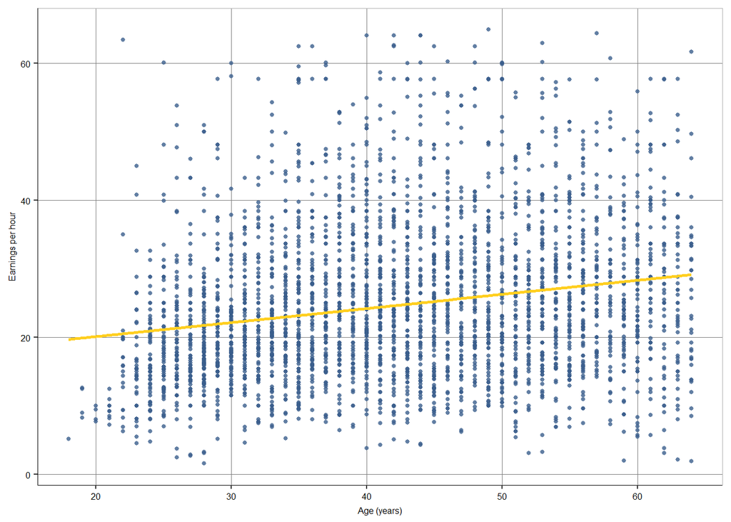

```r
#4. Selecting functional form - log or sq of X's

# age sqaured
#adding the square of the variable allows you to model more accurately the effect of age, which may have a non-linear relationship with the independent variable. For instance, the effect of age could be positive up until, say, the age of 50, and then negative thereafter.

#Adding the age squared to age, allows you to model the effect a differing ages, rather than assuming the effect is linear for all ages.

data <- data %>% mutate(agesq=age^2,
                        lnage = log(age))

plot_ageearnh <- ggplot(data = data, aes(x=data$age, y=earnh)) +
  geom_point( color = color[1], size = 1,  shape = 16, alpha = 0.8, show.legend=F,
              na.rm = TRUE) +
  geom_smooth(method="lm", se=F, colour=color[4], size=1, span=0.9) +
  labs(x = "Age (years)",y = "Earnings per hour") +
  theme_bg()


plot_ageearnh
```

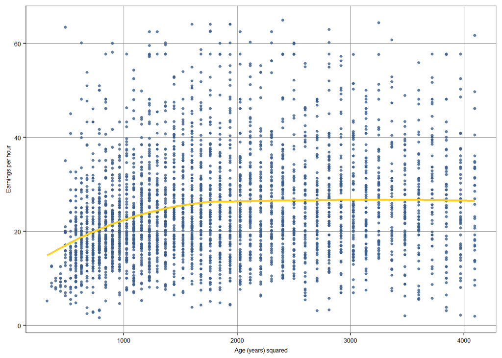

```r
# squared age
plot_age2earnh <- ggplot(data = data, aes(x=agesq, y=earnh)) +
  geom_point( color = color[1], size = 1,  shape = 16, alpha = 0.8, show.legend=F,
              na.rm = TRUE) +
  geom_smooth(method="loess", se=F, colour=color[4], size=1, span=0.9) +
  labs(x = "Age (years) squared",y = "Earnings per hour") +
  theme_bg()

plot_age2earnh
```

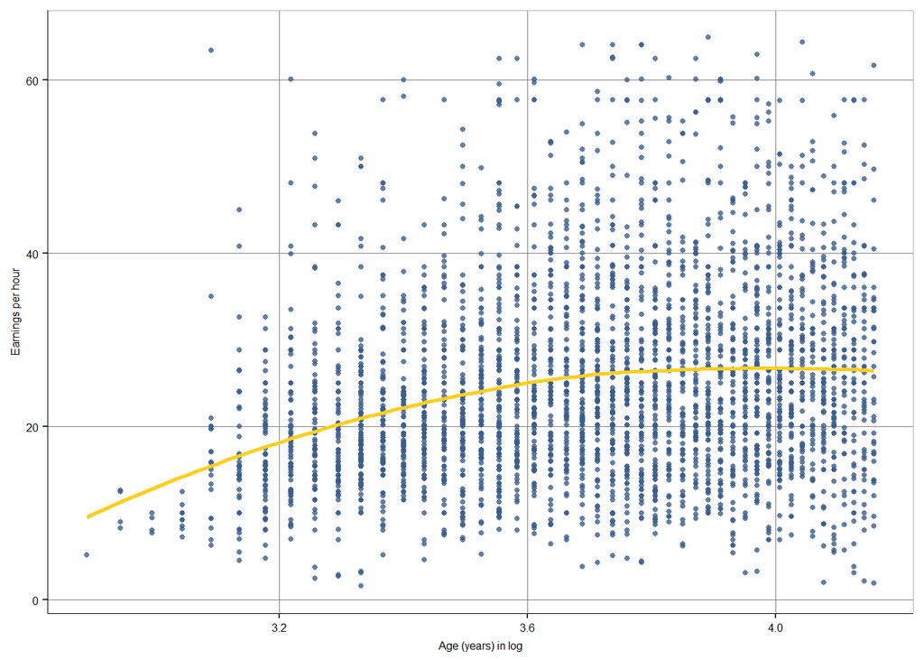

```r
plot_agelearnh <- ggplot(data = data, aes(x=lnage, y=earnh)) +
  geom_point( color = color[1], size = 1,  shape = 16, alpha = 0.8, show.legend=F,
              na.rm = TRUE) +
  geom_smooth(method="loess", se=F, colour=color[4], size=1, span=0.9) +
  labs(x = "Age (years) in log",y = "Earnings per hour") +
  theme_bg()

plot_agelearnh
```

### 5) Interactions

```r
#5. Thinking interactions
### add interactions, non-linear functional forms, additional variables

#Look at possible need for interactions by domain knowledge / visualization

#Education Level and Years of Experience: (age)
#the potential work experience proxied by age for males and females is different, that is, females experience more career interruptions than males

data <- data %>% mutate(female_age =female*age,
                        female_agesq =female*agesq,
                        female_lnage = female*lnage)

#Other ideas:
# occupation*region – industry and labour market structures that impact on wages differ between regions (have only one occupation) # do fixed effects with state

#occupation*age and occupation*age squared – the return to work experience may be different for different  occupations (have only one occupation)
```

# extend for all relevant variables!

```r
# data summary
#datasummary(earnh + age + agesq + lnage + female + female_age +female_agesq +female_lnage + native + private + white + union + married + divorced + wirowed + nevermar + child0 + child1 + child2 + child3 + child4plus  + edu_HighS +edu_BA + edu_MA + edu_Prof + edu_PhD    ~ Mean + Median + Min + Max + P25 + P75 + N , data = data )
```

```r
data <- data %>% mutate(train_index = sample(c("train","test"),nrow(data),replace=TRUE,prob =c(0.8,0.2)))

data_train <- data %>% filter(train_index == "train")

data_test <- data %>% filter(train_index == "test")
```

## Models

### The goal is to predict the earnings per hour that may be appropriate for teachers fulfilling certain criteria.

# do log model for comparison?

# Recommended variables to include by AI: https://chat.openai.com/share/44e6cfb2-6a2a-4c1d-a824-1618ae741cd7

### Model 1: the target variable is continous: earnings per hour (levels)

```r
#model_1 <- lm_robust(earnh ~  edu_BA + edu_MA + edu_Prof + edu_PhD, data,se_type = "HC1")
#summary(model_1)

model_1 <- lm(earnh ~  edu_BA + edu_MA + edu_Prof + edu_PhD, data)
summary(model_1)
```

```
##
## Call:
## lm(formula = earnh ~ edu_BA + edu_MA + edu_Prof + edu_PhD, data = data)
##
## Residuals:
##     Min      1Q  Median      3Q     Max
## -25.777  -7.488  -2.380   5.587  45.427
##
## Coefficients:
##             Estimate Std. Error t value Pr(>|t|)
## (Intercept)  17.0730     0.6385  26.737  < 2e-16 ***
## edu_BA        5.7994     0.6943   8.353  < 2e-16 ***
## edu_MA       10.3070     0.6894  14.950  < 2e-16 ***
## edu_Prof      9.4592     1.6920   5.590 2.44e-08 ***
## edu_PhD      13.9838     1.8176   7.693 1.84e-14 ***
## ---
## Signif. codes:  0 '***' 0.001 '**' 0.01 '*' 0.05 '.' 0.1 ' ' 1
##
## Residual standard error: 10.63 on 3549 degrees of freedom
## Multiple R-squared:  0.08014,    Adjusted R-squared:  0.07911
## F-statistic:  77.3 on 4 and 3549 DF,  p-value: < 2.2e-16
```

```r
pred_1 <- predict(model_1, data)
resid_pred1 <- pred_1-data$earnh
summary(resid_pred1)
```

```
##    Min. 1st Qu.  Median    Mean 3rd Qu.    Max.
## -45.427  -5.587   2.380   0.000   7.488  25.777
```

### Model 2: the target variable is continous: earnings per hour

```r
#model_2 <- lm_robust(earnh  ~  lnage + edu_BA + edu_MA + edu_Prof + edu_PhD, data, se_type = "HC1")

model_2 <- lm(earnh  ~  lnage + edu_BA + edu_MA + edu_Prof + edu_PhD, data)

summary(model_2)
```

```
##
## Call:
## lm(formula = earnh ~ lnage + edu_BA + edu_MA + edu_Prof + edu_PhD,
##     data = data)
##
## Residuals:
##     Min      1Q  Median      3Q     Max
## -25.811  -6.906  -1.956   4.992  44.866
##
## Coefficients:
##             Estimate Std. Error t value Pr(>|t|)
## (Intercept) -10.5019     2.4279  -4.325 1.56e-05 ***
## lnage         7.5282     0.6404  11.755  < 2e-16 ***
## edu_BA        5.8162     0.6812   8.538  < 2e-16 ***
## edu_MA        9.6842     0.6786  14.272  < 2e-16 ***
## edu_Prof      8.5633     1.6620   5.152 2.71e-07 ***
## edu_PhD      12.7152     1.7867   7.116 1.33e-12 ***
## ---
## Signif. codes:  0 '***' 0.001 '**' 0.01 '*' 0.05 '.' 0.1 ' ' 1
##
## Residual standard error: 10.43 on 3548 degrees of freedom
## Multiple R-squared:  0.1146, Adjusted R-squared:  0.1134
## F-statistic: 91.87 on 5 and 3548 DF,  p-value: < 2.2e-16
```

```r
pred_2 <- predict(model_2, data)
resid_pred2 <- pred_2-data$earnh
summary(resid_pred2)
```

```
##    Min. 1st Qu.  Median    Mean 3rd Qu.    Max.
## -44.866  -4.992   1.956   0.000   6.906  25.811
```

```r
#model_2 <- lm(earnh  ~ age  + lnage + edu_BA + edu_MA + edu_Prof + edu_PhD, data)
# OLDDD
# age as proxy for experience
#model_1a <- lm(earnh ~ age + agesq, data)
#model_1b <- lm(earnh ~ age + data$lnage, data)
#model_1c <- lm(earnh ~ age + agesq + lnage, data)


#model_1 <- lm_robust(earnh ~ age + agesq, data, se_type = "HC1")
#summary(model_1b)


#model_2 <- lm(earnh ~  edu_BA + edu_MA + edu_Prof + edu_PhD, data)
#summary(model_2)

# earn ~ grade92 + age + agesq + sex + sector
```

### Model 3: the target variable is continous: earnings per hour

```r
#model_3 <- lm_robust(earnh  ~ age  + lnage + edu_BA + edu_MA + edu_Prof + edu_PhD + female + union + native + private + white + married + divorced + wirowed + nevermar + child0 + + child1 + child2 + child3 + child4plus, data, se_type = "HC1")

model_3 <- lm(earnh  ~ age  + lnage + edu_BA + edu_MA + edu_Prof + edu_PhD + female + union + native + private + white + married + divorced + wirowed + nevermar + child0 + + child1 + child2 + child3 + child4plus, data)

summary(model_3)
```

```
##
## Call:
## lm(formula = earnh ~ age + lnage + edu_BA + edu_MA + edu_Prof +
##     edu_PhD + female + union + native + private + white + married +
##     divorced + wirowed + nevermar + child0 + +child1 + child2 +
##     child3 + child4plus, data = data)
##
## Residuals:
##     Min      1Q  Median      3Q     Max
## -26.933  -6.778  -1.807   4.694  49.110
##
## Coefficients: (2 not defined because of singularities)
##             Estimate Std. Error t value Pr(>|t|)
## (Intercept) -59.6300    14.3776  -4.147 3.44e-05 ***
## age          -0.4889     0.1325  -3.690 0.000228 ***
## lnage        26.8596     5.3444   5.026 5.26e-07 ***
## edu_BA        4.4510     0.6774   6.571 5.73e-11 ***
## edu_MA        7.5532     0.6882  10.975  < 2e-16 ***
## edu_Prof      6.7850     1.6313   4.159 3.27e-05 ***
## edu_PhD      10.6037     1.7529   6.049 1.61e-09 ***
## female       -2.9423     0.4480  -6.568 5.85e-11 ***
## union         4.0386     0.3684  10.962  < 2e-16 ***
## native       -0.5726     0.8512  -0.673 0.501182
## private       0.3799     0.4470   0.850 0.395461
## white         0.2194     0.5423   0.405 0.685772
## married      -0.3047     0.5420  -0.562 0.574040
## divorced     -0.7020     0.7323  -0.959 0.337834
## wirowed       0.7018     1.8343   0.383 0.702057
## nevermar          NA         NA      NA       NA
## child0        0.5453     0.4843   1.126 0.260239
## child1        0.4235     0.8185   0.517 0.604934
## child2        0.1460     1.0272   0.142 0.886973
## child3        1.2510     0.5862   2.134 0.032883 *
## child4plus        NA         NA      NA       NA
## ---
## Signif. codes:  0 '***' 0.001 '**' 0.01 '*' 0.05 '.' 0.1 ' ' 1
##
## Residual standard error: 10.17 on 3535 degrees of freedom
## Multiple R-squared:  0.1602, Adjusted R-squared:  0.156
## F-statistic: 37.48 on 18 and 3535 DF,  p-value: < 2.2e-16
```

```r
pred_3 <- predict(model_3, data)
resid_pred3 <- pred_3-data$earnh
summary(resid_pred3)
```

```
##    Min. 1st Qu.  Median    Mean 3rd Qu.    Max.
## -49.110  -4.694   1.807   0.000   6.778  26.933
```

### Model 4: the target variable is continous: earnings per hour

## add interactions

```r
#model_4 <- lm_robust(earnh  ~ age  + lnage + edu_BA + edu_MA + edu_Prof + edu_PhD + female + union + native + private + white + married + divorced + wirowed + nevermar + child0 + + child1 + child2 + child3 + child4plus + female_age + female_lnage, data = data,se_type = "HC1")

model_4 <- lm(earnh  ~ age  + lnage + edu_BA + edu_MA + edu_Prof + edu_PhD + female + union + native + private + white + married + divorced + wirowed + nevermar + child0 + + child1 + child2 + child3 + child4plus + female_age + female_lnage, data = data)
summary(model_4)
```

```
##
## Call:
## lm(formula = earnh ~ age + lnage + edu_BA + edu_MA + edu_Prof +
##     edu_PhD + female + union + native + private + white + married +
##     divorced + wirowed + nevermar + child0 + +child1 + child2 +
##     child3 + child4plus + female_age + female_lnage, data = data)
##
## Residuals:
##     Min      1Q  Median      3Q     Max
## -26.818  -6.750  -1.789   4.725  48.771
##
## Coefficients: (2 not defined because of singularities)
##               Estimate Std. Error t value Pr(>|t|)
## (Intercept)  -75.44231   28.98053  -2.603  0.00927 **
## age           -0.56098    0.26592  -2.110  0.03497 *
## lnage         31.97038   10.80874   2.958  0.00312 **
## edu_BA         4.40713    0.67785   6.502 9.06e-11 ***
## edu_MA         7.49784    0.68892  10.883  < 2e-16 ***
## edu_Prof       6.71712    1.63188   4.116 3.94e-05 ***
## edu_PhD       10.51499    1.75365   5.996 2.23e-09 ***
## female        15.16611   30.90541   0.491  0.62365
## union          4.04370    0.36899  10.959  < 2e-16 ***
## native        -0.57200    0.85115  -0.672  0.50160
## private        0.36887    0.44703   0.825  0.40934
## white          0.19665    0.54241   0.363  0.71697
## married       -0.32546    0.54231  -0.600  0.54846
## divorced      -0.69713    0.73226  -0.952  0.34115
## wirowed        0.75702    1.83533   0.412  0.68002
## nevermar            NA         NA      NA       NA
## child0         0.56632    0.48480   1.168  0.24282
## child1         0.40062    0.81893   0.489  0.62473
## child2         0.15328    1.02780   0.149  0.88146
## child3         1.24148    0.58615   2.118  0.03424 *
## child4plus          NA         NA      NA       NA
## female_age     0.07625    0.28503   0.268  0.78907
## female_lnage  -5.75866   11.54254  -0.499  0.61788
## ---
## Signif. codes:  0 '***' 0.001 '**' 0.01 '*' 0.05 '.' 0.1 ' ' 1
##
## Residual standard error: 10.17 on 3533 degrees of freedom
## Multiple R-squared:  0.1609, Adjusted R-squared:  0.1562
## F-statistic: 33.88 on 20 and 3533 DF,  p-value: < 2.2e-16
```

```r
pred_4 <- predict(model_4, data)
resid_pred4 <- pred_4-data$earnh
summary(resid_pred4)
```

```
##    Min. 1st Qu.  Median    Mean 3rd Qu.    Max.
## -48.771  -4.725   1.789   0.000   6.750  26.818
```

#model 5 FE - is OLS but than eval diff..

```r
model_5 <- feols(earnh ~ age  + lnage + edu_BA + edu_MA + edu_Prof + edu_PhD | stfips, data ,vcov = "HC1")

summary(model_5)
```

```
## OLS estimation, Dep. Var.: earnh
## Observations: 3,554
## Fixed-effects: stfips: 51
## Standard-errors: Heteroskedasticity-robust
##           Estimate Std. Error  t value   Pr(>|t|)
## age      -0.503383   0.112071 -4.49166 7.2956e-06 ***
## lnage    27.765045   4.452335  6.23606 5.0229e-10 ***
## edu_BA    5.755231   0.662232  8.69065  < 2.2e-16 ***
## edu_MA    8.597049   0.676031 12.71695  < 2.2e-16 ***
## edu_Prof  7.024009   1.457192  4.82024 1.4949e-06 ***
## edu_PhD  11.982754   2.136508  5.60857 2.1984e-08 ***
## ---
## Signif. codes:  0 '***' 0.001 '**' 0.01 '*' 0.05 '.' 0.1 ' ' 1
## RMSE: 9.90981     Adj. R2: 0.186231
##                 Within R2: 0.11048
```

```r
models <- c("model_1", "model_2","model_3", "model_4")
BIC <- c()
RMSE <- c()
RSquared <- c()
regr <- c()
k <- c()
library(Metrics)
# Get for all models
for ( i in 1:length(models)){
  BIC[i] <- BIC(get(models[i]))
  RMSE[i] <- rmse(predict(get(models[i])), get(models[i])$model$earnh)
  RSquared[i] <-summary(get(models[i]))$r.squared
  regr[[i]] <- coeftest(get(models[i]), vcov = sandwich)
  k[i] <- get(models[i])$rank -1
}


evaluation <- data.frame(models, k, RSquared, RMSE, BIC)
evaluation
```

```
##    models  k   RSquared     RMSE      BIC
## 1 model_1  4 0.08014445 10.61999 26929.21
## 2 model_2  5 0.11462888 10.41903 26801.59
## 3 model_3 18 0.16024836 10.14705 26719.87
## 4 model_4 20 0.16093159 10.14292 26733.33
```

```r
evaluation <- evaluation %>%
  mutate(models = paste0("(",gsub("reg","",models),")")) %>%
  rename(Model = models, "R-squared" = RSquared, "RMSE (full)" = RMSE, "N predictors" = k)
evaluation
```

```
##       Model N predictors  R-squared RMSE (full)      BIC
## 1 (model_1)            4 0.08014445    10.61999 26929.21
## 2 (model_2)            5 0.11462888    10.41903 26801.59
## 3 (model_3)           18 0.16024836    10.14705 26719.87
## 4 (model_4)           20 0.16093159    10.14292 26733.33
```

```r
stargazer(evaluation, summary = F,sep="")
```

```
##
## % Table created by stargazer v.5.2.3 by Marek Hlavac, Social Policy Institute. E-mail: marek.hlavac at gmail.com
## % Date and time: Fr., Nov 10, 2023 - 17:08:31
## \begin{table}[!htbp] \centering
##   \caption{}
##   \label{}
## \begin{tabular}{@{\extracolsep{5pt}} ccccc}
## \\[-1.8ex]\hline
## \hline \\[-1.8ex]
## (model\_1) & $4$ & $0.080$ & $10.620$ & $26,929.220$ \\
## (model\_2) & $5$ & $0.115$ & $10.419$ & $26,801.590$ \\
## (model\_3) & $18$ & $0.160$ & $10.147$ & $26,719.870$ \\
## (model\_4) & $20$ & $0.161$ & $10.143$ & $26,733.330$ \\
## \hline \\[-1.8ex]
## \end{tabular}
## \end{table}
##
## % Table created by stargazer v.5.2.3 by Marek Hlavac, Social Policy Institute. E-mail: marek.hlavac at gmail.com
## % Date and time: Fr., Nov 10, 2023 - 17:08:31
## \begin{table}[!htbp] \centering
##   \caption{}
##   \label{}
## \begin{tabular}{@{\extracolsep{5pt}} c}
## \\[-1.8ex]\hline
## \hline \\[-1.8ex]
##  \\
## \hline \\[-1.8ex]
## \end{tabular}
## \end{table}
```

```r
set.seed(123)
```

```r
# graphs
```